# Estudo de Caso 03: Comparação de desempenho de duas configurações de um algoritmo de otimização

EEE933 - Planejamento e Análise de Experimentos — PPGEE/UFMG

Adonai Arruda, Alexandra Milaya Soto Aponte, João Paulo Gonçalves Simim, Yasmim Machado

05 de outubro de 2026

# 1 Resumo

# 2 Introdução

Algoritmos baseados em populações são frequentemente utilizados em problemas de otimização em engenharia. Neles, um conjunto de soluções candidatas é submetido iterativamente a operadores de variação e seleção, explorando o espaço de busca em direção ao mínimo (ou máximo) de uma função objetivo.

Entre esses algoritmos, destaca-se o metodo de **evolução diferencial** (DE, do inglês *Differential Evolution*), proposta por Storn e Price (1997), cujo funcionamento pode ser resumido assim:

**Entrada:** $N$ (tamanho da população), $n_{\text{iter}}$ (número de iterações), $\text{recpars}$ e $\text{mutpars}$ (parâmetros de recombinação e mutação).

1. **Inicialização:** $t \leftarrow 0$; gerar a população inicial $X_t = \{\vec{x}_1,\ldots,\vec{x}_N\}$ e avaliar $\vec{f}_t \leftarrow f(X_t)$.
2. **Enquanto** $t < n_{\text{iter}}$:
   1. **Mutação:** $V_t \leftarrow \operatorname{mutação}(X_t,\text{mutpars})$
   2. **Recombinação:** $U_t \leftarrow \operatorname{recombinação}(X_t,V_t,\text{recpars})$
   3. **Avaliação:** $\vec{j}_t \leftarrow f(U_t)$
   4. **Seleção:** $(X_{t+1},\vec{f}_{t+1}) \leftarrow \operatorname{seleção}(X_t,U_t,\vec{f}_t,\vec{j}_t)$
   5. $t \leftarrow t+1$
3. **Saída:** população final e valores da função objetivo, $(X_t,\vec{f}_t)$.

Neste estudo, o critério de parada é um número máximo de avaliações da função objetivo ($5000 \cdot \text{dim}$), e o desempenho de cada execução é medido pelo melhor valor encontrado (`Fbest`). Valores menores indicam melhor desempenho.

O objetivo é comparar duas configurações do DE na classe de problemas formada pelas funções de Rosenbrock com dimensão entre 2 e 150. Cada configuração combina um operador de recombinação e um de mutação. Neste caso de estudo particular, ambas configurações usam a mutação `mutation_rand`, mas com fatores de escala $F$ diferentes:

- **Configuração 1:** recombinação por linha (*line recombination*) do *Breeder Genetic Algorithm* (BGA), `recombination_lbga`; mutação *rand* com $F = 4{,}5$.
- **Configuração 2:** *Blend Crossover* Alpha-Beta (BLX-$\alpha\beta$), `recombination_blxAlphaBeta`, com $\alpha = 0{,}1$ e $\beta = 0{,}4$; mutação *rand* com $F = 3$.

# 3 Planejamento do Experimento

## 3.1 Objetivo e hipóteses

O objeto deste experimento visa responder a três perguntas:

1. Existe diferença no desempenho médio das duas configurações na classe de problemas considerada?
2. Se existir, qual configuração é melhor e qual a magnitude da diferença?
3. Os resultados justificam recomendar uma configuração em relação à outra?

Seja $Y_{ij}$ o desempenho médio da configuração $i$ na instância $j$, correspondente a uma função de Rosenbrock de dimensão específica. Para comparar as duas configurações em uma mesma instância, define-se a diferença pareada de desempenho como:

$$\psi_j = Y_{2j} - Y_{1j}$$

Como o desempenho é avaliado pelo valor de `Fbest`, que deve ser minimizado, valores de $\psi_j > 0$ indicam que a configuração 1 apresentou melhor desempenho, enquanto valores de $\psi_j < 0$ favorecem a configuração 2.

Assim, define-se $\mu_D = E[\psi_j]$ como a diferença média esperada de desempenho entre as duas configurações, considerando o conjunto de instâncias avaliadas. Desta forma, as hipoteses a serem testadas afim de responder as pergutas do experiemento são:

$$\begin{cases}
H_0: \mu_D = 0 \\
H_1: \mu_D \neq 0
\end{cases}$$

Onde, $H_0$ estabelece que não há diferença média de desempenho entre as duas configurações, enquanto $H_1$ admite diferença em qualquer direção. Já, o sinal da estimativa de $\mu_D$ e seu intervalo de confiança indicarão qual configuração é melhor,caso $H_0$ seja rejeitada.

## 3.2 Coleta dos dados e Tamanho amostral

O planejamento do experimento exige a definição de dois tamanhos amostrais, seguindo a metodologia de Campelo e Takahashi (2019):

1. o número de instâncias, $N$, suficiente para detectar a diferença de interesse e representativo da classe de problemas, isto é, funções de Rosenbrock com dimensão entre 2 e 150;
2. o número de repetições de cada configuração em cada instância, $n_{ij}$, que permita estimar com precisão adequada o desempenho médio da configuração $i$ na instância $j$.

### 3.2.1 Número de instâncias ($N$)

O enunciado do estudo de caso (referência) estabelece os seguintes parâmetros experimentais:

- Mínima diferença de importância prática (padronizada): $d^* = \delta^*/\sigma = 0{,}5$
- Nível de significância: $\alpha = 0{,}05$
- Potência mínima (para $d = d^*$): $\pi = 1 - \beta = 0{,}8$

Com base nesses valores, realizou-se uma análise de potência para o teste t pareado bilateral, a fim de determinar o menor número de instâncias capaz de detectar uma diferença de importância prática com o nível de significância e a potência especificados. Como $d^*$ já é uma quantidade padronizada, utilizaram-se `delta = 0.5` e `sd = 1`.

```
##
##      Paired t test power calculation
##
##               n = 33.3672
##           delta = 0.5
##              sd = 1
##       sig.level = 0.05
##           power = 0.8
##     alternative = two.sided
##
## NOTE: n is number of *pairs*, sd is std.dev. of *differences* within pairs
```

O resultado foi $n = 33{,}4$, que, arredondado para cima, corresponde a $N^* = 34$ instâncias. As duas configurações são avaliadas nas mesmas instâncias, o que garante o pareamento dos dados.

Para que as instâncias constituam uma amostra representativa da classe de problemas, as $N^* = 34$ dimensões foram sorteadas aleatoriamente, sem reposição, entre os inteiros de 2 a 150, com semente fixa para garantir a reprodutibilidade. As instâncias avaliadas são apresentadas a seguir:

**Dimensões selecionadas:** 4, 9, 13, 32, 35, 36, 39, 43, 45, 46, 49, 57, 59, 62, 67, 80, 89, 92, 94, 99, 100, 101, 102, 109, 111, 112, 114, 115, 122, 127, 131, 132, 134, 148 .

### 3.2.2 Número de repetições ($n_{ij}$)

Para determinar o número de repetições de cada configuração em cada instância, implementou-se o Algoritmo 1 de Campelo e Takahashi (2019). Em cada instância, o algoritmo executa inicialmente $n_0$ repetições de cada configuração e, em seguida, acrescenta uma repetição por vez até que o erro padrão da diferença de desempenho $\psi_j$ atinja a precisão desejada, ou até que um orçamento máximo de execuções, $n_{max}$, seja alcançado. As repetições adicionais são alocadas preferencialmente à configuração de maior variância, de modo que $n_{1j}$ e $n_{2j}$ podem ser diferentes.

Quanto a $n_0$, os autores recomendam basear a escolha na forma da distribuição do desempenho do algoritmo: valores baixos (3 ou 4) para distribuições aproximadamente gaussianas, em torno de 10 para outras distribuições simétricas e 20 ou 30 para distribuições fortemente assimétricas. Adotou-se $n_0 = 20$, valor que atende bem à maioria dos casos. Nas instâncias em que a variabilidade é maior, o algoritmo acrescenta repetições até alcançar a precisão desejada. O orçamento máximo foi fixado em $n_{max} = 200$ execuções por instância, somando as duas configurações.

## 3.3 Análise exploratória e tratamento dos dados

As inferências deste experimento são realizadas sobre $\psi_j$, a diferença de desempenho médio entre as configurações na instância $j$. Por isso, os dados brutos obtidos das execuções do algoritmo passaram por duas etapas de processamento:

1. para cada dimensão (instância), calculou-se o desempenho médio de cada configuração, $\bar{F}_{1j}$ e $\bar{F}_{2j}$, a partir das $n_{1j}$ e $n_{2j}$ repetições do melhor valor encontrado (`Fbest`);
2. a partir dessas médias, calculou-se a diferença $\psi_j^{\text{bruto}} = \bar{F}_{2j} - \bar{F}_{1j}$, observação amostral da diferença de desempenho na instância $j$, na escala original.

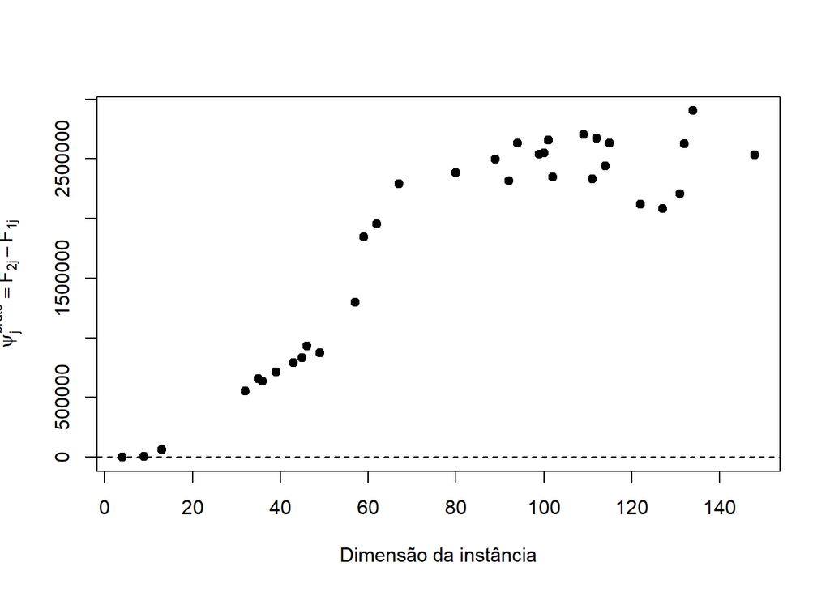

(#fig:grafico_diferencas)Diferença de desempenho médio entre as configurações em cada instância, em função da dimensão (escala original).

Para compreender melhor o comportamento dos dados, selecionou-se uma subamostra de 9 das 34 instâncias, distribuídas ao longo do intervalo de dimensões para representar instâncias de baixa, média e alta dimensão.

**Dimensões selecionadas para a análise exploratória:** 4, 9, 32, 49, 62, 92, 94, 102, 122 .

A Figura 3.1 mostra os dados brutos de desempenho de ambas as configurações. Em linhas gerais, os dados indicam que:

- em todas as instâncias do subconjunto, a configuração 1 apresenta melhor desempenho, isto é, valores de `Fbest` menores;
- nas instâncias de menor dimensão o algoritmo alcança valores menores do que nas de maior dimensão, o que indica que é conveniente tratar os dados para colocar as instâncias em uma escala comparável.

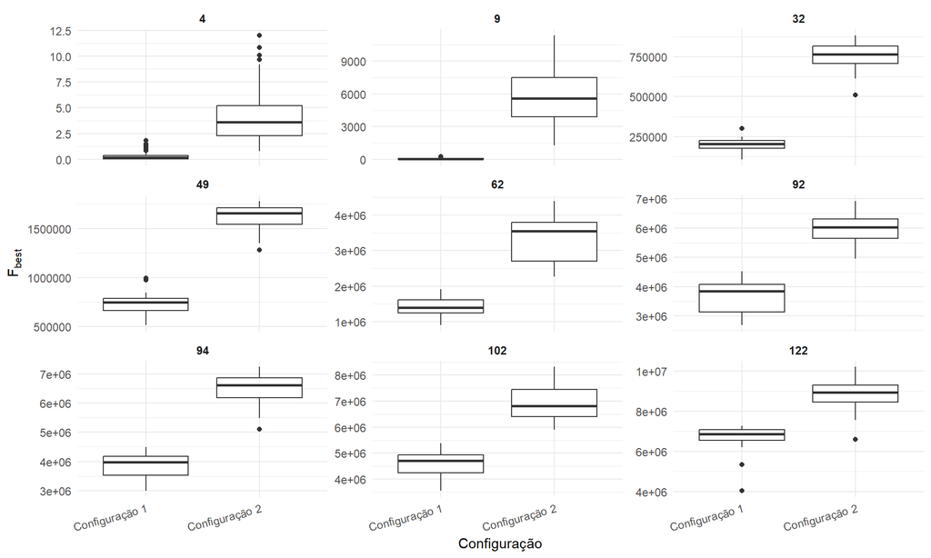

Figure 3.1: Distribuição do desempenho (Fbest) de cada configuração nas instâncias do subconjunto exploratório.

### 3.3.1 Normalidade das diferenças na escala original

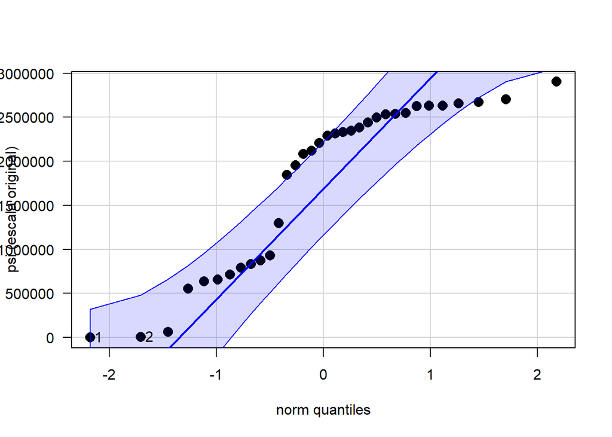

(#fig:qq_diferencas)Gráfico quantil-quantil das diferenças de desempenho na escala original.

### 3.3.2 Transformação logarítmica

Como a ordem de grandeza de `Fbest` varia fortemente com a dimensão, as diferenças foram calculadas sobre o logaritmo natural do desempenho. Define-se

$$\bar{Y}_{ij} = \frac{1}{n_{ij}} \sum_{k=1}^{n_{ij}} \log(F_{best,ijk}), \qquad \psi_j = \bar{Y}_{2j} - \bar{Y}_{1j},$$

em que $F_{best,ijk}$ é o valor obtido na repetição $k$ da configuração $i$ na instância $j$.

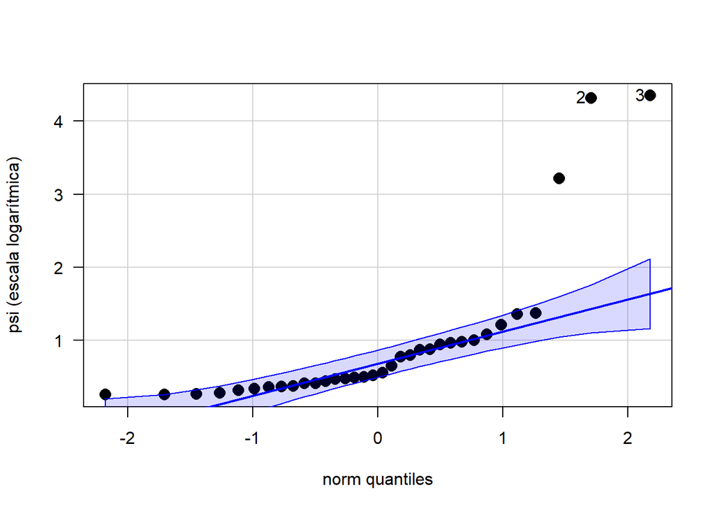

(#fig:qq_log)Gráfico quantil-quantil das diferenças de desempenho na escala logarítmica.

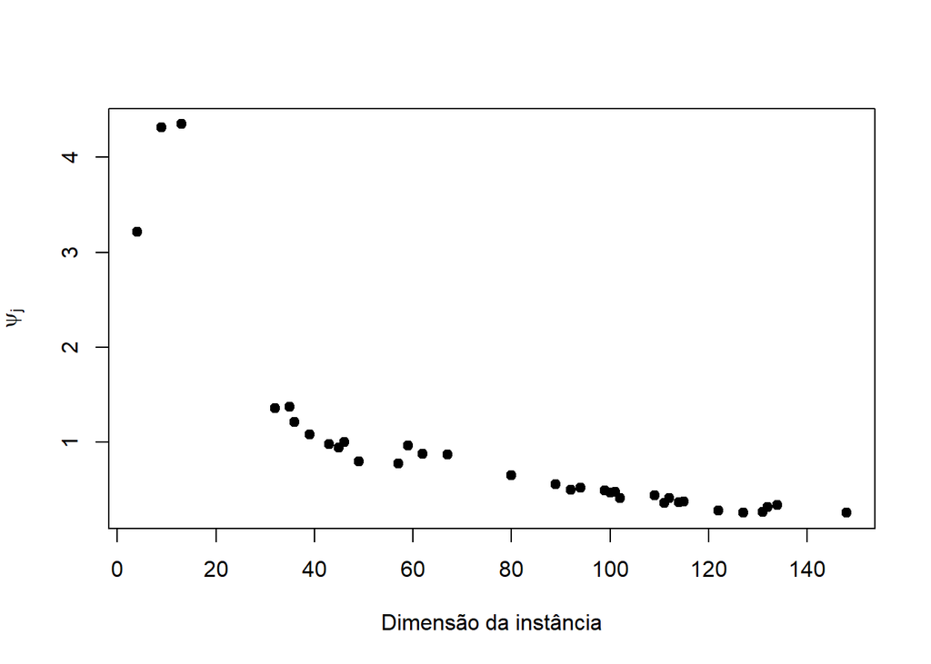

(#fig:grafico_diferencas_log)Diferença de desempenho na escala logarítmica, em função da dimensão.

# 4 Análise Estatística

## 4.7 Critério de desempate: análise de risco e variabilidade

# 5 Conclusões e Recomendações

# 6 Discussão da significância e dos riscos do teste

## 6.1 Nível de significância e controle do erro tipo I

## 6.2 Erro tipo II e potência dos testes

# 7 Possíveis melhorias do experimento

- A exploração dos dados com um piloto antes da execução das 34 instancias poderia ter otimizado os recursos computacionais ao fixar um n_0 mais conveniente para o conjunto de instancias.

# 8 Papéis desempenhados pela equipe

| Integrante | Papel |
| --- | --- |
| Adonai Arruda | Relator: |
| Alexandra Milaya Soto Aponte | Relatora/ Analista: Responsável pela programação e redação da Introdução e das seções de Planejamento do Experimento e Análise Exploratória dos Dados. |
| João Paulo Gonçalves Simim | Analista: |
| Yasmim Machado | Verificador: |

# 9 Declaração sobre o uso de IA generativa

Durante a preparação deste trabalho, os autores utilizaram o Claude (Anthropic) para:

- Implementar em R o Psudo-codigo do Algoritmo 1 desenvolvido por Campelo e Takahashi (2019) para determinar o numero de repetições $n_{ij$ até que o erro padrão da diferença de desempenho $\psi_j$ atinja a precisão desejada.
- Formatação de gráficos e tabelas

# 10 Referências

- BESSANI, M. Material da disciplina EEE933 - Planejamento e Análise de Experimentos (notas de aula sobre ANOVA e comparações múltiplas). PPGEE/UFMG, 2026.

# 11 Apêndice: desempenho médio por instância

(#tab:tabela_dados)Desempenho médio (escala original) e número de repetições por instância.

| Dimensão | Média Config. 1 | n1 | Média Config. 2 | n2 | Diferença (psi bruto) |
| --- | --- | --- | --- | --- | --- |
| 4 | 0.29 | 136 | 4.20 | 64 | 3.91 |
| 9 | 85.78 | 99 | 5949.01 | 75 | 5863.23 |
| 13 | 922.54 | 80 | 65316.87 | 54 | 64394.32 |
| 32 | 196419.13 | 20 | 750629.88 | 20 | 554210.75 |
| 35 | 237681.42 | 20 | 897031.14 | 20 | 659349.72 |
| 36 | 276990.44 | 20 | 914858.07 | 20 | 637867.63 |
| 39 | 370933.98 | 20 | 1085031.32 | 20 | 714097.34 |
| 43 | 500132.07 | 20 | 1292477.69 | 20 | 792345.62 |
| 45 | 555662.32 | 20 | 1389235.94 | 20 | 833573.63 |
| 46 | 556527.02 | 20 | 1487268.97 | 20 | 930741.94 |
| 49 | 736880.89 | 20 | 1613800.40 | 20 | 876919.51 |
| 57 | 1146780.69 | 20 | 2446673.39 | 20 | 1299892.70 |
| 59 | 1140902.48 | 20 | 2986936.01 | 20 | 1846033.52 |
| 62 | 1390624.72 | 20 | 3343388.07 | 20 | 1952763.35 |
| 67 | 1677880.71 | 20 | 3966622.34 | 20 | 2288741.63 |
| 80 | 2658236.29 | 20 | 5040589.99 | 20 | 2382353.70 |
| 89 | 3382518.55 | 20 | 5881098.24 | 20 | 2498579.69 |
| 92 | 3695349.74 | 20 | 6014122.68 | 20 | 2318772.94 |
| 94 | 3871183.78 | 20 | 6504508.42 | 20 | 2633324.64 |
| 99 | 4133132.88 | 20 | 6673817.15 | 20 | 2540684.27 |
| 100 | 4303422.73 | 20 | 6853335.75 | 20 | 2549913.02 |
| 101 | 4462125.51 | 20 | 7121242.93 | 20 | 2659117.43 |
| 102 | 4599981.35 | 20 | 6946558.42 | 20 | 2346577.06 |
| 109 | 4928367.35 | 20 | 7632129.88 | 20 | 2703762.53 |
| 111 | 5433973.70 | 20 | 7764172.98 | 20 | 2330199.29 |
| 112 | 5370913.09 | 20 | 8041262.86 | 20 | 2670349.77 |
| 114 | 5675793.99 | 20 | 8114445.98 | 20 | 2438652.00 |
| 115 | 5795081.30 | 20 | 8425711.51 | 20 | 2630630.21 |
| 122 | 6653460.52 | 20 | 8775081.97 | 20 | 2121621.45 |
| 127 | 7046260.34 | 20 | 9128671.14 | 20 | 2082410.81 |
| 131 | 7334573.90 | 20 | 9543824.79 | 20 | 2209250.89 |
| 132 | 7142759.32 | 20 | 9770546.04 | 20 | 2627786.72 |
| 134 | 7337425.27 | 20 | 10240711.48 | 20 | 2903286.21 |
| 148 | 8765676.62 | 20 | 11301341.95 | 20 | 2535665.33 |